# Cognitive load selectively interferes with utilitarian moral judgment

Joshua D. Greene, Sylvia A. Morelli, Kelly Lowenberg, Leigh E. Nystrom, Jonathan D. Cohen

December 17, 2022

## Introduction

In this project I will be reproducing the main finding of the paper, that is the effect of cognitive load on moral decision making. Greene et al, present 40 total vignettes of moral decisions that require either deontological (rule based) decisions or utilitarian (consequence based) decisions. While there is no difference in response time (RT) for either, with the presence of load, utilitarian responses have a longer RT on average. The study is a within-between design so all participants are in both no load and load groups and the RT is taken and averaged by judgement (deontolgical/utilitarian).

The main finding that I am looking to replicate is the effect of load on RT for utilitarian decision making. This would be a mixed effects linear model looking at the effect of moral choices and load condition on the response time.

### Justification for choice of study

I choose to replicate this study as it’s a seminal piece in moral psychology. Furthermore, I am interested in dual-process decision making theories and Greene’s work was informative for “fast/slow” models. This piece builds on previous work by Greene in 2001 and will become a key finding for their work in model-free, model based moral decision making, Kanheman’s “Thinking Fast Thinking Slow” and more.

### Anticipated challenges

One challenge I anticipate in attempting to replicate this study is getting sufficient responses from participants as there are many vinnettes and I could imagine that there will be a great deal of satisficing.

Further, I anticipate challenges with collecting similar response times.

### Links

Original paper (as hosted in your repo):

https://github.com/lynde-m-folsom/Replications/blob/main/Greene_Rep/Original_paper/Greene_Cohen_Cog2007.pdf

## Methods

### How we intend to replicate

First, designing a task that is similar to the original. This replication will be conducted online so the first challenge is replicating the task design for presenting the stimuli. The dilemmas are presented as scrolling text across a screen with the cognitive load condition including a scrolling number line.

Next, piloting the data to see that the response time (RT) is reasonable compared to the original paper. After gathering data, calculating the mean and standard deviations for load/no load conditions. Per original paper, RT is then trimmed to within 2standard deviations for each mean RT removing outliers. Finally a series of linear models to see if we can replicate the main effect in the paper.

Model 1: Effect of choices on RT: In this model we’re looking to see if utilitarian choices have a different RT compared to their non utilitarian counterparts.

Model 2: Effect of load conditions on RT: This model to see if the cognitive load condition effects the RT. We predict it will but authors found no effect until running the mixed effects model.

Model 3: Mixed effects model of choice and load on RT: This is the model that has the significant effects in the original paper wherein cognitive load selectively slows the RT of utilitarian choices. I predict this effect will not replicate.

### Differences from original study

One major difference is that I will be conducting this study online rather than in person. This means my population will not be Princeton undergraduates and may represent more diversity in age and other demographics. This may have a role in how people make moral decisions as well as things like reading speed and general response time.

Another major difference is that for the original study 40 dilemmas were presented and only 12 were included for the results. In this study I will only present the 12 that were used for their findings. This shortens the study significantly but also, I hope, prevents satisficing.

Finally, in making the task, the speed of the scrolling text and numbers is not replicable from the description in the paper. Using CSS code, for most devices the speed of the scrolling text should be hypothetically similar to the scrolling speed for the original study, however I cannot confirm that the speed is exactly 16character/s for every participant. During piloting, I intend to have a variety of devices such that I can confirm the speed of scrolling effect does not interfere with the capacity to read with the text.

### Measure of success

The measure of success here will be weather we can replicate the main finding of cognitive load selectively interfering with utilitarian choices. This would be demonstrated as a significant result in a mixed effect model of load * condition on RT with participants as a random effect.

## Results

### Data preparation

Data preparation following the analysis plan. #Library

### Bring in Data & organize it

```r
#### Import data
raw_data <- read_survey("Greene_08_Rep_121422.csv", legacy = TRUE) %>%
  clean_names()
#### Data exclusion / filtering
#grab the variables I want
df.data <- select(raw_data,
                  "prolific_id",
                  contains("l1"),
                  contains("l2"),
                  -contains("page_submit"),
                  -contains("last_click"),
                  -contains("click_count"))
#remove the pilot & qualtrics headers that I don't want
df.data <- df.data %>%
  filter(prolific_id !="beth")%>%
  filter(prolific_id !="kate") %>%
  filter(prolific_id !="ImportId") %>%
  filter(prolific_id !="test001_JWB") %>%
  filter(prolific_id !="asdf") %>%
  filter(prolific_id != '{"ImportId":"QID33_TEXT"}')
#### Prepare data for analysis - create columns etc.
df.datalong <- df.data %>%
  group_by("prolific_id") %>%
  pivot_longer(
    cols = !"prolific_id",
    names_to = c("trial", "load"),
    names_sep = "_",
    values_to = "choice")
df.datalong <- df.datalong %>%
  filter(choice != "prolific_id" )
## Pesky row that Anna helped move
odd.ind <- seq_len(nrow(df.datalong)) %% 2
df.datalong.odds <- df.datalong[odd.ind == 1, ]
df.datalong.evens <- df.datalong[odd.ind == 0, ]

df.datalong.odds$bin.choice <- df.datalong.evens$choice

df.datalong
```

```
# A tibble: 1,728 × 4
   prolific_id              trial load  choice
   <chr>                    <chr> <chr> <chr>
 1 60bc16d1f9aef5318d50167d t1    l1    1
 2 60bc16d1f9aef5318d50167d t1    l1    40.767
 3 60bc16d1f9aef5318d50167d t2    l1    1
 4 60bc16d1f9aef5318d50167d t2    l1    49.667
 5 60bc16d1f9aef5318d50167d t3    l1    1
 6 60bc16d1f9aef5318d50167d t3    l1    53.364
 7 60bc16d1f9aef5318d50167d t4    l1    2
 8 60bc16d1f9aef5318d50167d t4    l1    56.266
 9 60bc16d1f9aef5318d50167d t5    l1    1
10 60bc16d1f9aef5318d50167d t5    l1    44.464
# … with 1,718 more rows
```

```r
df.datalong.odds
```

```
# A tibble: 864 × 5
   prolific_id              trial load  choice bin.choice
   <chr>                    <chr> <chr> <chr>  <chr>
 1 60bc16d1f9aef5318d50167d t1    l1    1      40.767
 2 60bc16d1f9aef5318d50167d t2    l1    1      49.667
 3 60bc16d1f9aef5318d50167d t3    l1    1      53.364
 4 60bc16d1f9aef5318d50167d t4    l1    2      56.266
 5 60bc16d1f9aef5318d50167d t5    l1    1      44.464
 6 60bc16d1f9aef5318d50167d t6    l1    1      48.513
 7 60bc16d1f9aef5318d50167d t1    l2    2      53.741
 8 60bc16d1f9aef5318d50167d t2    l2    2      41.006
 9 60bc16d1f9aef5318d50167d t3    l2    1      45.175
10 60bc16d1f9aef5318d50167d t4    l2    1      47.43
# … with 854 more rows
```

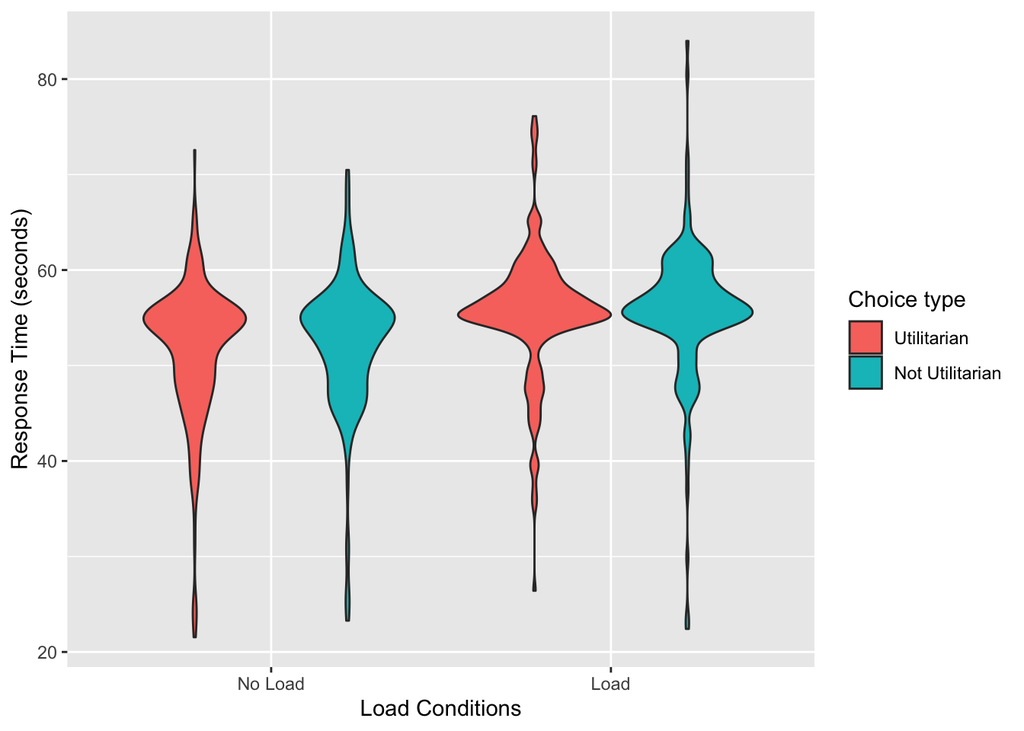

```r
new.df.datalong <- df.datalong.odds

df.datalong <-new.df.datalong %>%
  rename(rt = "bin.choice")

df.datalong <-df.datalong %>%
  mutate(rtnum = as.numeric(rt)) %>%
  mutate(choicenum = as.factor(choice))

## RT Trimming like in original paper

sumsdfdatalong <- df.datalong %>%
  group_by(load) %>%
  summarize(rtmean = mean(rtnum),
            stdrtmean = 2*sd(rtnum),
            minrt = rtmean-stdrtmean,
            maxrt = rtmean+stdrtmean)

minrt <- sumsdfdatalong$minrt
maxrt <- sumsdfdatalong$maxrt

df.datalongtrim <- df.datalong %>%
  group_by(load) %>%
  filter(rtnum > minrt) %>%
  filter(rtnum < maxrt)

## Lets see the data so far
df.datalongtrim %>%
  ggplot(mapping = aes(x = load,
         y = rtnum,
         fill = choicenum
        ))+
  geom_violin()+
  labs(x = "Load Conditions",
       y = "Response Time (seconds)")+
  scale_x_discrete(labels=c("l1" = "No Load",
                            "l2" = "Load"))+
  scale_fill_discrete(name="Choice type",
                  labels=c("1" = "Utilitarian",
                           "2" = "Not Utilitarian"))
```

### Key analysis

- 3 linear models (participant as random effect)
  - 1. RT ~ Choice
  - 2. RT ~ Load
  - 3. RT ~ Load * Choice
- Anova model comparisons
- Plot the results

```r
#modeling choice
m1<- lmer(rtnum ~choicenum +(1|prolific_id),
          data = df.datalongtrim)
report(m1)
```

```
We fitted a linear mixed model (estimated using REML and nloptwrap optimizer) to predict rtnum with choicenum (formula: rtnum ~ choicenum). The model included prolific_id as random effect (formula: ~1 | prolific_id). The model's total explanatory power is substantial (conditional R2 = 0.49) and the …

  - The effect of choicenum [2] is statistically non-significant and positive (beta = 0.76, 95% CI [-0.10, 1.61], t(791) = 1.73, p = 0.083; Std. beta = 0.11, 95% CI [-0.01, 0.23])

Standardized parameters were obtained by fitting the model on a standardized version of the dataset. 95% Confidence Intervals (CIs) and p-values were computed using
```

```r
summary(m1)
```

```
Linear mixed model fit by REML. t-tests use Satterthwaite's method [
lmerModLmerTest]
Formula: rtnum ~ choicenum + (1 | prolific_id)
   Data: df.datalongtrim

REML criterion at convergence: 5083.2

Scaled residuals:
    Min      1Q  Median      3Q     Max
-4.4981 -0.4197  0.0793  0.4745  4.6719

Random effects:
 Groups      Name        Variance Std.Dev.
 prolific_id (Intercept) 27.32    5.227
 Residual                28.19    5.309
Number of obs: 795, groups:  prolific_id, 72

Fixed effects:
            Estimate Std. Error       df t value Pr(>|t|)
(Intercept)  53.1577     0.6719  78.8768  79.111   <2e-16 ***
choicenum2    0.7566     0.4364 758.1595   1.734   0.0834 .
---
Signif. codes:  0 '***' 0.001 '**' 0.01 '*' 0.05 '.' 0.1 ' ' 1

Correlation of Fixed Effects:
           (Intr)
choicenum2 -0.278
```

```r
#modeling load
m2 <- lmer(rtnum ~load +(1|prolific_id),
           data = df.datalongtrim)
report(m2)
```

```
We fitted a linear mixed model (estimated using REML and nloptwrap optimizer) to predict rtnum with load (formula: rtnum ~ load). The model included prolific_id as random effect (formula: ~1 | prolific_id). The model's total explanatory power is substantial (conditional R2 = 0.55) and the part relat…

  - The effect of load [l2] is statistically significant and positive (beta = 3.59, 95% CI [2.89, 4.29], t(791) = 10.10, p < .001; Std. beta = 0.50, 95% CI [0.41, 0.60])

Standardized parameters were obtained by fitting the model on a standardized version of the dataset. 95% Confidence Intervals (CIs) and p-values were computed using
```

```r
summary(m2)
```

```
Linear mixed model fit by REML. t-tests use Satterthwaite's method [
lmerModLmerTest]
Formula: rtnum ~ load + (1 | prolific_id)
   Data: df.datalongtrim

REML criterion at convergence: 4990.9

Scaled residuals:
    Min      1Q  Median      3Q     Max
-5.0549 -0.3849  0.0635  0.4751  5.1037

Random effects:
 Groups      Name        Variance Std.Dev.
 prolific_id (Intercept) 27.00    5.196
 Residual                24.85    4.985
Number of obs: 795, groups:  prolific_id, 72

Fixed effects:
            Estimate Std. Error       df t value Pr(>|t|)
(Intercept)  51.6882     0.6627  78.9740   77.99   <2e-16 ***
loadl2        3.5910     0.3556 721.2864   10.10   <2e-16 ***
---
Signif. codes:  0 '***' 0.001 '**' 0.01 '*' 0.05 '.' 0.1 ' ' 1

Correlation of Fixed Effects:
       (Intr)
loadl2 -0.267
```

```r
#model the load*choice and rt
m3 <- lmer(rtnum ~load *choicenum +(1|prolific_id),
           data = df.datalongtrim)
report(m3)
```

```
We fitted a linear mixed model (estimated using REML and nloptwrap optimizer) to predict rtnum with load and choicenum (formula: rtnum ~ load * choicenum). The model included prolific_id as random effect (formula: ~1 | prolific_id). The model's total explanatory power is substantial (conditional R2 …

  - The effect of load [l2] is statistically significant and positive (beta = 4.01, 95% CI [3.07, 4.95], t(789) = 8.41, p < .001; Std. beta = 0.56, 95% CI [0.43, 0.70])
  - The effect of choicenum [2] is statistically non-significant and positive (beta = 0.82, 95% CI [-0.28, 1.92], t(789) = 1.46, p = 0.144; Std. beta = 0.12, 95% CI [-0.04, 0.27])
  - The interaction effect of choicenum [2] on load [l2] is statistically non-significant and negative (beta = -1.05, 95% CI [-2.50, 0.40], t(789) = -1.42, p = 0.155; Std. beta = -0.15, 95% CI [-0.35, 0.06])

Standardized parameters were obtained by fitting the model on a standardized version of the dataset. 95% Confidence Intervals (CIs) and p-values were computed using
```

```r
summary(m3)
```

```
Linear mixed model fit by REML. t-tests use Satterthwaite's method [
lmerModLmerTest]
Formula: rtnum ~ load * choicenum + (1 | prolific_id)
   Data: df.datalongtrim

REML criterion at convergence: 4987.2

Scaled residuals:
    Min      1Q  Median      3Q     Max
-5.0437 -0.3848  0.0564  0.4657  5.0542

Random effects:
 Groups      Name        Variance Std.Dev.
 prolific_id (Intercept) 27.14    5.210
 Residual                24.82    4.982
Number of obs: 795, groups:  prolific_id, 72

Fixed effects:
                  Estimate Std. Error       df t value Pr(>|t|)
(Intercept)        51.3770     0.6974  95.3172  73.673   <2e-16 ***
loadl2              4.0102     0.4766 721.3052   8.415   <2e-16 ***
choicenum2          0.8204     0.5616 741.4926   1.461    0.144
loadl2:choicenum2  -1.0490     0.7374 724.0550  -1.422    0.155
---
Signif. codes:  0 '***' 0.001 '**' 0.01 '*' 0.05 '.' 0.1 ' ' 1

Correlation of Fixed Effects:
            (Intr) loadl2 chcnm2
loadl2      -0.307
choicenum2  -0.305  0.383
ldl2:chcnm2  0.207 -0.660 -0.678
```

```r
#looking at model comparisons
anova(m2, m3)
```

```
refitting model(s) with ML (instead of REML)
```

```
Data: df.datalongtrim
Models:
m2: rtnum ~ load + (1 | prolific_id)
m3: rtnum ~ load * choicenum + (1 | prolific_id)
   npar    AIC    BIC  logLik deviance  Chisq Df Pr(>Chisq)
m2    4 4999.7 5018.4 -2495.8   4991.7
m3    6 5001.2 5029.2 -2494.6   4989.2 2.4809  2     0.2893
```

```r
anova(m1, m2)
```

```
refitting model(s) with ML (instead of REML)
```

```
Data: df.datalongtrim
Models:
m1: rtnum ~ choicenum + (1 | prolific_id)
m2: rtnum ~ load + (1 | prolific_id)
   npar    AIC    BIC  logLik deviance  Chisq Df Pr(>Chisq)
m1    4 5092.3 5111.1 -2542.2   5084.3
m2    4 4999.7 5018.4 -2495.8   4991.7 92.693  0
```

```r
anova(m1, m3)
```

```
refitting model(s) with ML (instead of REML)
```

```
Data: df.datalongtrim
Models:
m1: rtnum ~ choicenum + (1 | prolific_id)
m3: rtnum ~ load * choicenum + (1 | prolific_id)
   npar    AIC    BIC  logLik deviance  Chisq Df Pr(>Chisq)
m1    4 5092.3 5111.1 -2542.2   5084.3
m3    6 5001.2 5029.2 -2494.6   4989.2 95.174  2  < 2.2e-16 ***
---
Signif. codes:  0 '***' 0.001 '**' 0.01 '*' 0.05 '.' 0.1 ' ' 1
```

```r
#save model outputs to make a figure
means <- estimate_means(m3)
```

```
We selected `at = c("load", "choicenum")`.
```

```r
as.factor(means$load) #this will make the graphing easier
```

```
[1] l1 l2 l1 l2
Levels: l1 l2
```

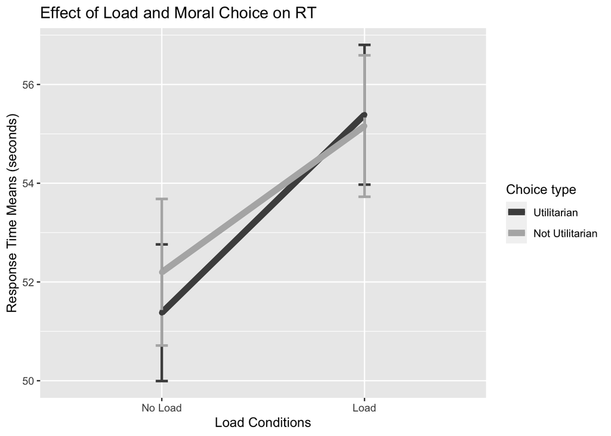

```r
means %>%
  ggplot(mapping = aes(x = load,
                       y = Mean,
                       group = choicenum,
                       color = choicenum
                        ))+
  geom_line(linewidth = 2.5)+
  geom_errorbar(aes(ymin=CI_low, ymax=CI_high), width=.06, size = 1)+
  geom_point()+
  labs(title = "Effect of Load and Moral Choice on RT",
       x = "Load Conditions",
       y = "Response Time Means (seconds)")+
  scale_x_discrete(labels=c("l1" = "No Load",
                            "l2" = "Load"))+
  scale_colour_grey(name="Choice type",
                  labels=c("1" = "Utilitarian",
                           "2" = "Not Utilitarian"),
                  start = 0.3,
                  end = 0.7)
```

### Compare to the original figure

[figure not shown]

Original author’s figure

## Discussion

### Summary of Reproduction Attempt

We found that RT significantly increases with the presence ense of load which confirms our hypothesis. However, this differs from the original paper which does not find this effect until running the mixed effect model. Further, we find that our RT mean is significantly different from the original RTs reported (original= 5.8s appx, current study = 52s). And finally we do not find a significant difference between utilitarian/non utilitarian choice under load.

### Commentary

Considering the failure to replicate the effect, follow up questions I have for this study are as follows.

Further, the scrolling text makes for a challenging task without introducing a load component, I would like to see how RT and judgment is effected by introducing scrolling text.

The content of the dilemmas are very similar. I believe this introduces a possible meta-cognitive factor that can reduce the cognitive load of the task by responding in a “heuristic” kind of way.

Finally, the dilemmas all follow a similar model based off the trolley problem but with extreme consequences. I’m unsure the ecological validity of running graphic moral dilemmas to represent moral choices. These dilemmas are based off of philosophical thought experiments designed to solicit specific hypothetical responses not to solicit realistic responding. By adding graphic elements to the task I’m unsure if we get closer to understanding the relationship between cognitive processes and moral decision making.